# **Reproducible Research Course Project 1**

Patricia Rose Donato

### **Loading and preprocessing the data**

```r
library(readr)
activity <- read_csv("C:/Users/pdonato/Desktop/Coursera/RepData_PeerAssessment1/activity.zip")
activity$date <- as.Date(activity$date,format="%Y %b %d")
```

The process starts with loading the data and changing the format of the date to make it easier to read. Missing values are not yet treated.

### **What is mean total number of steps taken per day?**

```r
total_steps <- activity %>%
  group_by(date) %>%
  summarise(totsteps = sum(steps, na.rm=TRUE))

kable(total_steps,
      col.names = c("Date","Total Steps"),
      format.args = list(big.mark = ","),
      caption = "Table 1. Total Steps per Day",
      align = "cl") %>%
  kable_styling(bootstrap_options = c("striped", "hover"), full_width = F, font_size = 15) %>%
  column_spec(1, width = "5cm") %>%
  column_spec(2, width = "5cm") %>%
  row_spec(0, align = "c")
```

Table 1. Total Steps per Day

| Date | Total Steps |
| --- | --- |
| 2012-10-01 | 0 |
| 2012-10-02 | 126 |
| 2012-10-03 | 11,352 |
| 2012-10-04 | 12,116 |
| 2012-10-05 | 13,294 |
| 2012-10-06 | 15,420 |
| 2012-10-07 | 11,015 |
| 2012-10-08 | 0 |
| 2012-10-09 | 12,811 |
| 2012-10-10 | 9,900 |
| 2012-10-11 | 10,304 |
| 2012-10-12 | 17,382 |
| 2012-10-13 | 12,426 |
| 2012-10-14 | 15,098 |
| 2012-10-15 | 10,139 |
| 2012-10-16 | 15,084 |
| 2012-10-17 | 13,452 |
| 2012-10-18 | 10,056 |
| 2012-10-19 | 11,829 |
| 2012-10-20 | 10,395 |
| 2012-10-21 | 8,821 |
| 2012-10-22 | 13,460 |
| 2012-10-23 | 8,918 |
| 2012-10-24 | 8,355 |
| 2012-10-25 | 2,492 |
| 2012-10-26 | 6,778 |
| 2012-10-27 | 10,119 |
| 2012-10-28 | 11,458 |
| 2012-10-29 | 5,018 |
| 2012-10-30 | 9,819 |
| 2012-10-31 | 15,414 |
| 2012-11-01 | 0 |
| 2012-11-02 | 10,600 |
| 2012-11-03 | 10,571 |
| 2012-11-04 | 0 |
| 2012-11-05 | 10,439 |
| 2012-11-06 | 8,334 |
| 2012-11-07 | 12,883 |
| 2012-11-08 | 3,219 |
| 2012-11-09 | 0 |
| 2012-11-10 | 0 |
| 2012-11-11 | 12,608 |
| 2012-11-12 | 10,765 |
| 2012-11-13 | 7,336 |
| 2012-11-14 | 0 |
| 2012-11-15 | 41 |
| 2012-11-16 | 5,441 |
| 2012-11-17 | 14,339 |
| 2012-11-18 | 15,110 |
| 2012-11-19 | 8,841 |
| 2012-11-20 | 4,472 |
| 2012-11-21 | 12,787 |
| 2012-11-22 | 20,427 |
| 2012-11-23 | 21,194 |
| 2012-11-24 | 14,478 |
| 2012-11-25 | 11,834 |
| 2012-11-26 | 11,162 |
| 2012-11-27 | 13,646 |
| 2012-11-28 | 10,183 |
| 2012-11-29 | 7,047 |
| 2012-11-30 | 0 |

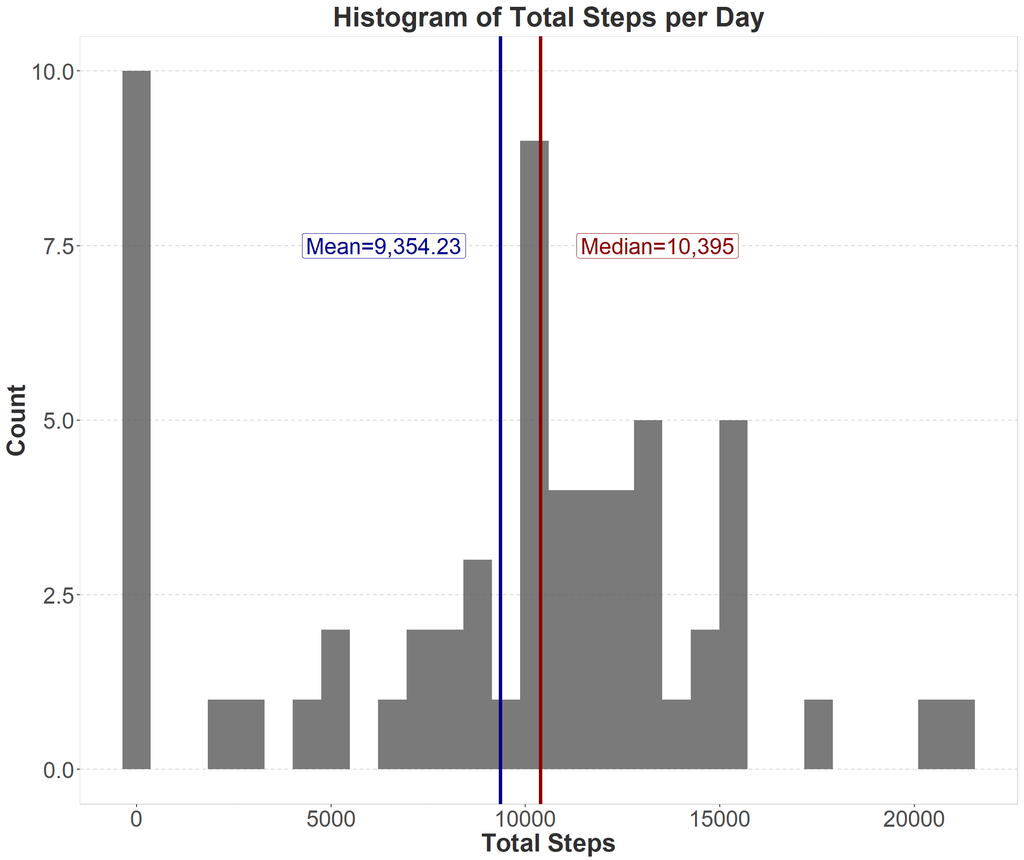

```r
ggplot(data=total_steps, aes(x=totsteps, y=..count..)) +
  geom_histogram(alpha=0.8) +
  geom_vline(xintercept=mean(total_steps$totsteps), size=1.5, color="darkblue") +
  geom_vline(xintercept=median(total_steps$totsteps), size=1.5, color="darkred") +
  geom_label(aes(x=median(total_steps$totsteps), y=7.5,
                 label=paste0("Median=",median(total_steps$totsteps)%>% format(big.mark=","))),
            nudge_x = 3000,
            color = "darkred",
            show.legend = FALSE,
            size=7) +
  geom_label(aes(x=mean(total_steps$totsteps), y=7.5,
                 label=paste0("Mean=",mean(total_steps$totsteps) %>% format(big.mark=","))),
            nudge_x = -3000,
            color = "darkblue",
            show.legend = FALSE,
            size=7) +
  xlab("Total Steps") +
  ylab("Count") +
  ggtitle("Histogram of Total Steps per Day") +
  theme(axis.text.x = element_text(vjust = 0.5,size=20),
        text = element_text(family = "sans", color = "#303030", size = 20),
        title = element_text(face = "bold", color = "#303030", size = 23),
        axis.text=element_text(size=20),
        axis.title = element_text(size=22, face="bold"),
        plot.title = element_text(size=24, hjust = 0.5),
        plot.subtitle = element_text(face="italic"),
        plot.caption = element_text(hjust = 0, size=22, color ="#3A5199",face="italic"),
        panel.background = element_rect(fill="white", color ="#D3D3D3"),
        panel.grid.major.y = element_line(colour="#D3D3D3",linetype = "dashed"),
        strip.text.x = element_text(size = 20))
```

```r
mean <- mean(total_steps$totsteps) %>% format(big.mark=",")
median <- median(total_steps$totsteps) %>% format(big.mark=",")
```

### **What is the average daily activity pattern?**

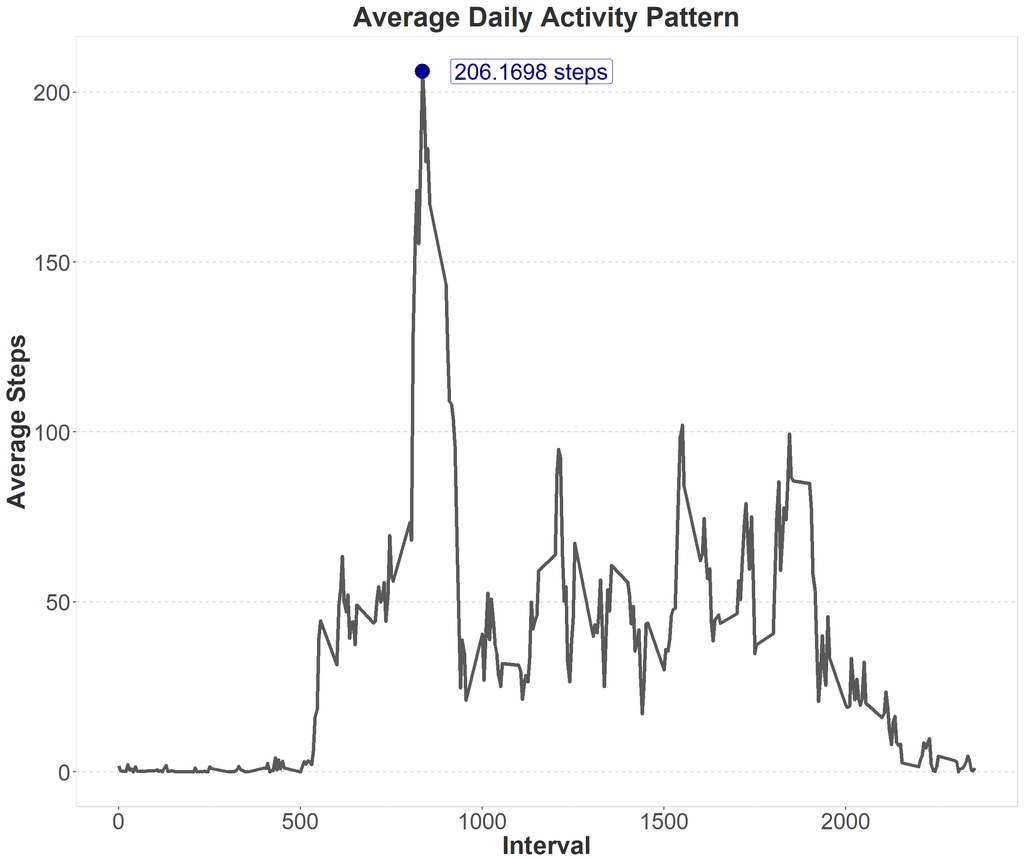

```r
daily_pattern <- activity %>%
  group_by(interval) %>%
  summarise(ave=mean(steps,na.rm=TRUE))

ggplot(data=daily_pattern, aes(x=interval, y=ave)) +
  geom_line(size=1.5,color="#303030",alpha=0.8) +
  geom_point(x=daily_pattern[which.max(daily_pattern$ave),1] %>% as.numeric(),
             y=max(daily_pattern$ave),
             size=6, color="darkblue") +
  geom_label(aes(x=daily_pattern[which.max(daily_pattern$ave),1] %>% as.numeric(),
                 y=max(daily_pattern$ave),
                 label=paste0(max(daily_pattern$ave) %>% format(big.mark=",")," steps")),
            nudge_x = 300,
            color = "darkblue",
            show.legend = FALSE,
            size=7) +
  xlab("Interval") +
  ylab("Average Steps") +
  ggtitle("Average Daily Activity Pattern") +
  theme(axis.text.x = element_text(vjust = 0.5,size=20),
        text = element_text(family = "sans", color = "#303030", size = 20),
        title = element_text(face = "bold", color = "#303030", size = 23),
        axis.text=element_text(size=20),
        axis.title = element_text(size=22, face="bold"),
        plot.title = element_text(size=24, hjust = 0.5),
        plot.subtitle = element_text(face="italic"),
        plot.caption = element_text(hjust = 0, size=22, color ="#3A5199",face="italic"),
        panel.background = element_rect(fill="white", color ="#D3D3D3"),
        panel.grid.major.y = element_line(colour="#D3D3D3",linetype = "dashed"),
        strip.text.x = element_text(size = 20))
```

```r
max <- daily_pattern[which.max(daily_pattern$ave),1] %>% as.numeric()
```

A typical day shows a peak in activity at early morning at 835AM, steeply going down at around 10AM. Steps start to gradually slow down at around 8PM.

### **Imputing missing values**

```r
missing <- sum(is.na(activity))
```

```r
daily_pattern <- activity %>%
  group_by(interval) %>%
  summarise(ave=mean(steps,na.rm=TRUE))

imputed_df <- left_join(activity,daily_pattern) %>%
  mutate(imputed_steps = ifelse(is.na(steps),ave,steps)) %>%
  select(date,interval,imputed_steps)

imputed_df_head <- left_join(activity,daily_pattern) %>%
  mutate(imputed_steps = ifelse(is.na(steps),ave,steps)) %>%
  select(date,interval,imputed_steps) %>%
  head(10)

kable(imputed_df_head,
      col.names = c("Date","Interval","Imputed Steps"),
      format.args = list(big.mark = ","),
      caption = "Table 2. First 10 Rows of Activity Data with Imputed Steps",
      align = "ccl") %>%
  kable_styling(bootstrap_options = c("striped", "hover"), full_width = F, font_size = 15) %>%
  column_spec(1, width = "5cm") %>%
  column_spec(2, width = "5cm") %>%
  column_spec(3, width = "5cm") %>%
  row_spec(0, align = "c")
```

Table 2. First 10 Rows of Activity Data with Imputed Steps

| Date | Interval | Imputed Steps |
| --- | --- | --- |
| 2012-10-01 | 0 | 1.7169811 |
| 2012-10-01 | 5 | 0.3396226 |
| 2012-10-01 | 10 | 0.1320755 |
| 2012-10-01 | 15 | 0.1509434 |
| 2012-10-01 | 20 | 0.0754717 |
| 2012-10-01 | 25 | 2.0943396 |
| 2012-10-01 | 30 | 0.5283019 |
| 2012-10-01 | 35 | 0.8679245 |
| 2012-10-01 | 40 | 0.0000000 |
| 2012-10-01 | 45 | 1.4716981 |

The missing values were imputed using the average interval steps for the whole period. Say, if there is a missing step at 01 Oct 2012 at 0 interval, then it was replaced by the average steps at 0 interval given the whole period, otherwise, the actual steps was used. Table 2 shows the first 10 rows of the data after missing values were treated.

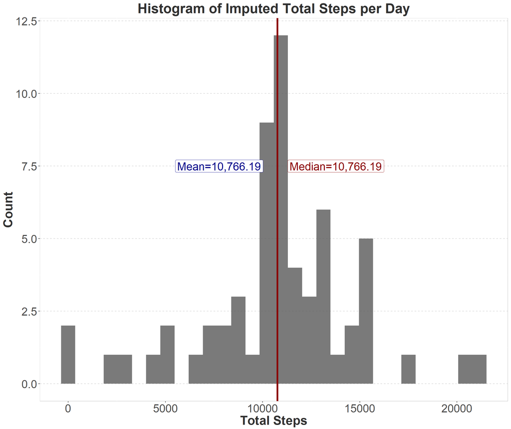

```r
imputed_total_steps <- imputed_df %>%
  group_by(date) %>%
  summarise(totsteps = sum(imputed_steps))

ggplot(data=imputed_total_steps, aes(x=totsteps, y=..count..)) +
  geom_histogram(alpha=0.8) +
  geom_vline(xintercept=mean(imputed_total_steps$totsteps), size=1.5, color="darkblue") +
  geom_vline(xintercept=median(imputed_total_steps$totsteps), size=1.5, color="darkred") +
  geom_label(aes(x=median(imputed_total_steps$totsteps), y=7.5,
                 label=paste0("Median=",median(imputed_total_steps$totsteps)%>% format(big.mark=","))),
            nudge_x = 3000,
            color = "darkred",
            show.legend = FALSE,
            size=7) +
  geom_label(aes(x=mean(imputed_total_steps$totsteps), y=7.5,
                 label=paste0("Mean=",mean(imputed_total_steps$totsteps) %>% format(big.mark=","))),
            nudge_x = -3000,
            color = "darkblue",
            show.legend = FALSE,
            size=7) +
  xlab("Total Steps") +
  ylab("Count") +
  ggtitle("Histogram of Imputed Total Steps per Day") +
  theme(axis.text.x = element_text(vjust = 0.5,size=20),
        text = element_text(family = "sans", color = "#303030", size = 20),
        title = element_text(face = "bold", color = "#303030", size = 23),
        axis.text=element_text(size=20),
        axis.title = element_text(size=22, face="bold"),
        plot.title = element_text(size=24, hjust = 0.5),
        plot.subtitle = element_text(face="italic"),
        plot.caption = element_text(hjust = 0, size=22, color ="#3A5199",face="italic"),
        panel.background = element_rect(fill="white", color ="#D3D3D3"),
        panel.grid.major.y = element_line(colour="#D3D3D3",linetype = "dashed"),
        strip.text.x = element_text(size = 20))
```

```r
imputed_mean <- mean(imputed_total_steps$totsteps) %>% format(big.mark=",")
imputed_median <- median(imputed_total_steps$totsteps) %>% format(big.mark=",")
```

After treating the missing values, it turns out that the mean and median is the same at 10,766.19.

### **Are there differences in activity patterns between weekdays and weekends?**

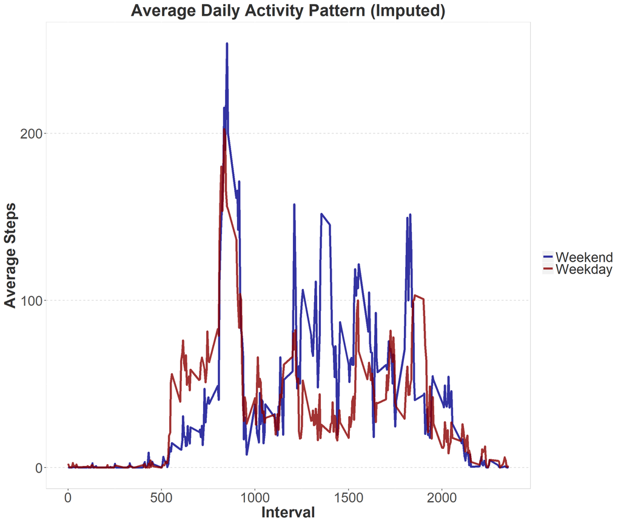

```r
imputed_df <- imputed_df %>%
  mutate(weekday = ifelse(wday(date) <= 5,1,0))

imputed_daily_pattern <- rbind(
  imputed_df %>%
    filter(weekday == 1) %>%
    group_by(interval) %>%
    summarise(ave=mean(imputed_steps)) %>%
    mutate(weekday=1),
  imputed_df %>%
    filter(weekday == 0) %>%
    group_by(interval) %>%
    summarise(ave=mean(imputed_steps)) %>%
    mutate(weekday=0)
)

ggplot(data=imputed_daily_pattern, aes(x=interval, y=ave, color=as.factor(weekday))) +
  geom_line(size=1.5,alpha=0.8) +
  scale_color_manual(name="",labels=c("Weekend","Weekday"),values=c("darkblue", "darkred")) +
  xlab("Interval") +
  ylab("Average Steps") +
  ggtitle("Average Daily Activity Pattern (Imputed)") +
  theme(axis.text.x = element_text(vjust = 0.5,size=20),
        text = element_text(family = "sans", color = "#303030", size = 20),
        title = element_text(face = "bold", color = "#303030", size = 23),
        axis.text=element_text(size=20),
        axis.title = element_text(size=22, face="bold"),
        plot.title = element_text(size=24, hjust = 0.5),
        plot.subtitle = element_text(face="italic"),
        plot.caption = element_text(hjust = 0, size=22, color ="#3A5199",face="italic"),
        panel.background = element_rect(fill="white", color ="#D3D3D3"),
        panel.grid.major.y = element_line(colour="#D3D3D3",linetype = "dashed"),
        strip.text.x = element_text(size = 20),
        legend.text=element_text(size=20))
```